# Simulation using the HND model

**LAST UPDATE AT**

```
## [1] "Fri Feb 10 13:05:06 2017"
```

## Preparations

We first set global chunk options and load the neccessary packages.

```r
library(knitr)
library(reshape2)
library(concaveFDR)
library(ggplot2)
library(grid)
library(locfdr)
library(fdrtool)
library(devtools)

if (!("mixfdr" %in%  (installed.packages()[, 1]))) {
  devtools::install_url("https://cran.r-project.org/src/contrib/Archive/mixfdr/mixfdr_1.0.tar.gz")
}

library(BiocParallel)
library(tidyverse)
library(grid)
library(RColorBrewer)

opts_chunk$set(fig.width=14, fig.height=10, cache=T,
error=FALSE, cache.lazy=FALSE)
options(digits = 2, scipen = 10)

multicoreParam <- MulticoreParam(workers = round(parallel::detectCores() * 0.75),
                                 catch.errors = FALSE)
multicoreParam
```

```
## class: MulticoreParam
##   bpisup: FALSE; bpnworkers: 3; bptasks: 0; bpjobname: BPJOB
##   bplog: FALSE; bpthreshold: INFO; bpstopOnError: TRUE
##   bptimeout: 2592000; bpprogressbar: FALSE
##   bpRNGseed:
##   bplogdir: NA
##   bpresultdir: NA
##   cluster type: FORK
```

```r
register(multicoreParam)
```

## Set parameters for the simulation

We now set parameters to simulate “z-scores” distributed according to the HND model (Rice and Spiegelhalter, 2008, Klaus and Strimmmer, 2011) and create some helper functions.

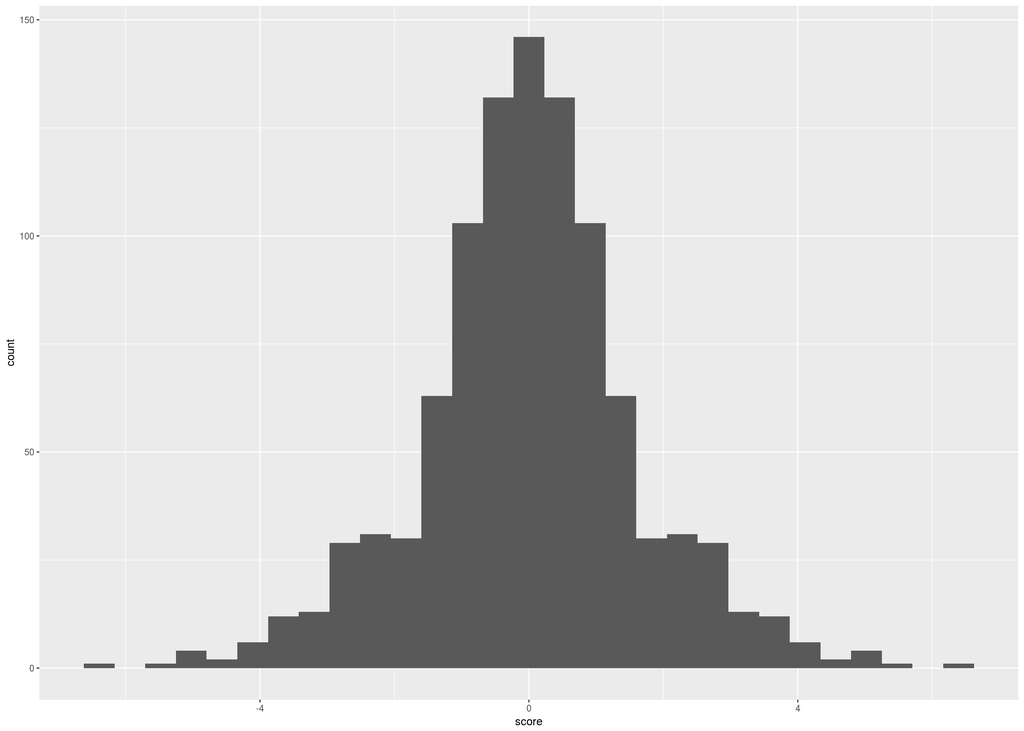

```r
### number of reps
B = 1000
### number of stats
d = 1000
### prop of null
eta0 = 0.8
### sigma
sigma = 1

### grid for true fdrs
s = seq(0.01,10,by=0.01)

## FDR functions for the HND model
Fdr.HNDscore = function(x)  concaveFDR:::HND(abs(x),  concaveFDR:::eta02k(eta0))
fdr.HNDscore = function(x)  concaveFDR:::hnd(abs(x),  concaveFDR:::eta02k(eta0))

## true FDRs
truefdr =  fdr.HNDscore(s)
trueFDR = Fdr.HNDscore(s)


### test it
score <- concaveFDR:::get.random.HNDscore(1000, eta0)
qplot(score)
```

We have a total of `d` z-values and we repeat the simulation `B` times (B=1000)

## Simulate HND scores

We now simulate the HND test statistics.

```r
##  d z-scores in every column
  HNDMat  <- t(laply(bplapply(seq_len(B), function(i){
    get.random.HNDscore(d)
    }), identity))

save(HNDMat, file = "HNDMat.rda")

hist(get.random.HNDscore(1000), breaks = 100)

hist(HNDMat[1:1000,1], breaks = 100)
z <- HNDMat[1:1000,1]
```

Load the presimulated HND scores

```r
load("HNDMat.rda")
```

## Helper functions

The following helpfer functions run various FDR estimation algorithms and return the estimated fdr for the grid points as given by `s`.

```r
mix.fdr.fun = function(z,P,J,empnull=FALSE){
  theonull = !empnull
  a = NA
    if(theonull) a = 1
    e = mixFdr(z[1:d],J=J, P = P, theonull = theonull, noiseSD = a, calibrate =
    FALSE, plots = FALSE, nocheck = TRUE)
    ind = abs(e$mu - e$mu[1])<=.1
    tmp = (fdrMixModel(s,e,ind))
    sigma = e$sigma[1]
    eta_0 = e$pi[1]
    return ( list (lfdr = tmp , eta_0 = eta_0,  sigma = sigma ))
    #return(tailFDRMixModel(s, e, ind)$tailFDR)
}

#test = mix.fdr.fun(z,P=50,J=3,empnull = TRUE)

loc.fdr.fun = function(z){

    loc = locfdr(z, plot = 0)
    eta_0 = loc$fp0["mlest","p0"]
    sigma = loc$fp0["mlest","sigma"]

    res = loc$fdr
    tmp = approx(x = z[1:d], y= res, xout = s)$y
    tmp[which(is.na(tmp))] = 0.0 #replace NAs by 0.0

    return ( list (lfdr = tmp , eta_0 = eta_0,  sigma = sigma ))
}

#test = loc.fdr.fun(z)
#plot(s,test$lfdr)

#test = loc.fdr.fun(z)


fdrtool.fdr.fun = function(z, met = "fndr"){
    tool = fdrtool(z[1:d], "normal",plot=FALSE, verbose =FALSE, cutoff.method =
    met)
    res = tool$lfdr

    #sp = splinefun(z, logit(pmax(pmin(res,0.999),.001)), method = "natural")
    #pmin(1,pmax(0,logistic(sp(s))))
    tmp = approx(x = z[1:d], y= res, xout = s)$y
    tmp[which(is.na(tmp))] = 0.0 #replace NAs by 0.0

  return ( list (lfdr = tmp , eta_0 = tool$param[3],  sigma = tool$param[5]))
}

#test = fdrtool.fdr.fun(z)
#plot(s,test$lfdr, type = "l")


##theo = FALSE; classic = FALSE
concaveFDR.fun = function(z){
  res = concaveFDR(z[1:d], "normal",plot=FALSE, verbose =FALSE, cutoff.method =
  "smoothing")
  fdr = res$lfdr.log


  tmp = approx(x = z[1:d], y= fdr, xout = s)$y
  tmp[which(is.na(tmp))] = 0.0 #replace NAs by 0.0
  return ( list (lfdr = tmp , eta_0 = res$param[3],  sigma = res$param[5]))
}

#test = concaveFDR.fun(z)
#plot(s,test$lfdr, type = "l")


HND.sigma.fdr.fun = function(z){

    param.out = concaveFDR:::hnd.fitnull(z,"normal")
    eta0 = param.out$eta0
        sd = param.out$sd

    pval = 2-2*pnorm(abs(z/sd))


    ### compute FDR values
    az = qnorm(1-pval/2)
    k = concaveFDR:::eta02k(eta0)

    #Fdr = HND(az, k)
    fdr = concaveFDR:::hnd(az, k)


tmp=approx(x = z[1:d], y= fdr , xout = s)$y
tmp[which(is.na(tmp))] = 0.0 #replace NAs by 0.0
  return ( list (lfdr = tmp , eta_0 = eta0,  sigma = sd ))
}

#test = HND.sigma.fdr.fun(z)
#plot(s,test$lfdr, type = "l")


#external empirical null

HND.fdr.fun = function(z){

  res = concaveFDR(z[1:d], "normal",plot=FALSE, verbose =FALSE, cutoff.method =
  "smoothing")
  fdr = res$lfdr.log

    eta_0 = res$param[3]
    sd = res$param[5]
     pval =res$pval

    # pv = pval.log
    ### compute FDR values
    az = qnorm(1-pval/2)
  k =  concaveFDR:::eta02k(eta0)

    #Fdr = HND(az, k)
    fdr = concaveFDR:::hnd(az, k)


tmp=approx(x = z[1:d], y= fdr , xout = s)$y
tmp[which(is.na(tmp))] = 0.0 #replace NAs by 0.0
  return ( list (lfdr = tmp , eta_0 = eta_0,  sigma = sd ))
}

#test = HND.fdr.fun(z)
#plot(s,test[1:d])
#plot(s,test$lfdr, type = "l")
####################################
```

## Run FDR estimation algorithms

We can now run the estimation algorithms and save the results

```r
fdrResults <- bplapply(seq_len(B), function(i){
   return(list(mixfdrEMP =  mix.fdr.fun(HNDMat[,i], J = 3, P=round(0.2*d),
                                         empnull=TRUE),
               locfdrMLE = loc.fdr.fun(HNDMat[,i]),
               fdrtoolEmp = fdrtool.fdr.fun(HNDMat[,i]),
               resHNDEmp = HND.sigma.fdr.fun(HNDMat[,i]),
               resHND = HND.fdr.fun(HNDMat[,i]),
               resConcave = concaveFDR.fun(HNDMat[,i])
               ))
  })
save(fdrResults, file = "fdrEstimationResults.RData")
```

```r
load("fdrEstimationResults.RData")
#display.brewer.pal(6, name ="Set3")

pal <- brewer.pal(6, name ="Dark2")
names(pal) <- c("mixfdrEMP", "locfdrMLE",
                "fdrtoolEmp", "resHNDEmp",  "resHND" ,  "resConcave")
```

## Produce plots

Here we produce some plots to evaluate the estimation results graphically. We first define some helper functions for the plots

```r
getVarFDR <- function(fdr) mean((fdr-truefdr)^2)
getVarFDRsub <- function(fdr) mean((fdr[truefdr < 0.2] - truefdr[truefdr < 0.2])^2)
#   grid.newpage()
#   pushViewport(viewport(layout = grid.layout(3, 1)))
#     print(den.plot, vp = vplayout(1, 1))

    vplayout <- function(x, y){
    viewport(layout.pos.row = x, layout.pos.col = y)
    }
```

### fdr accuracy plots

```r
## get accuracy for all methods
dataAcc <- as.data.frame(plyr::laply(bplapply(fdrResults, function(X){
   return(sapply(X, function(Y){getVarFDR(Y$lfdr) }))
  }),identity))

dataAcc <- melt(dataAcc, variable.name = "Method", value.name = "MSE")
```

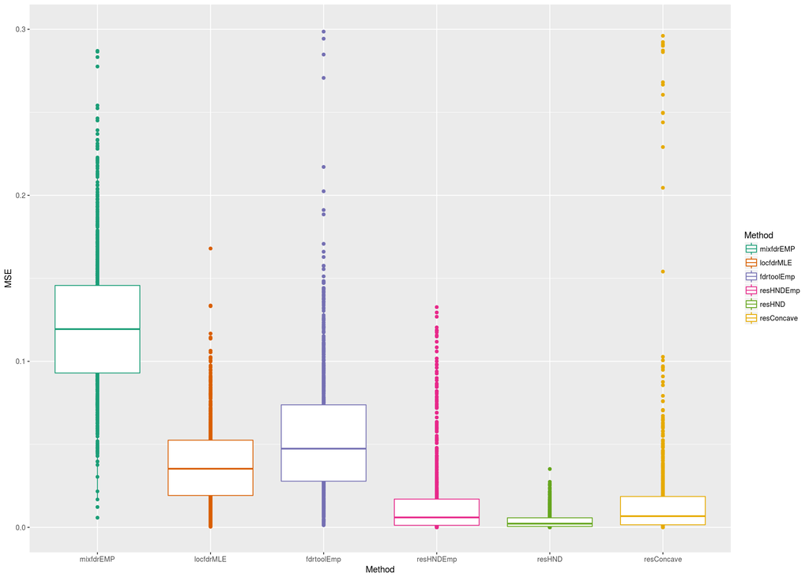

```r
(qplot(Method, MSE, data = dataAcc, color = Method) + geom_boxplot()
    + ylim(0,.3) + scale_color_manual(values = c(pal)))
```

### fdr accuracy plots subset with fdr < 0.2

```r
## get accuracy for all methods
dataAccSub <- as.data.frame(plyr::laply(bplapply(fdrResults, function(X){
   return(sapply(X, function(Y){getVarFDRsub(Y$lfdr) }))
  }),identity))

dataAccSub <- melt(dataAccSub, variable.name = "Method", value.name = "MSE")
```

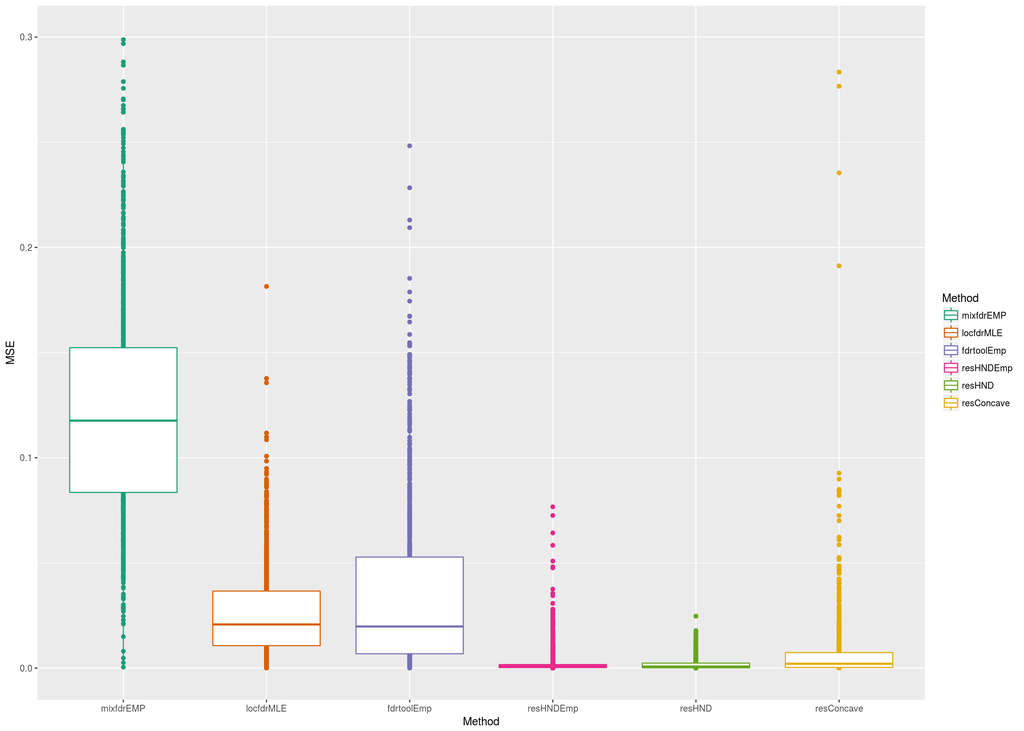

```r
(qplot(Method, MSE, data = dataAccSub, color = Method) + geom_boxplot()
    + ylim(0,.3) + scale_color_manual(values = c(pal)))
```

### fdr bias plots

We now produce bias plot for the fdr curve by computing the mean over all simulation runs.

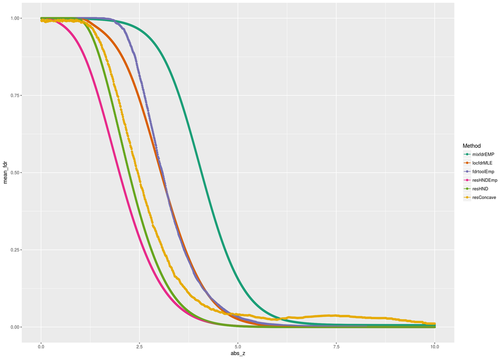

```r
dataBias <- lapply(bplapply(fdrResults, function(X){
   return(lapply(X, function(Y){Y$lfdr}))
  }), function(Z){ plyr::mutate(as.data.frame(Z), abs_z=s )})
dataBias <- plyr::ldply(dataBias, identity)
dataBias <- plyr::ddply(dataBias, "abs_z", apply, 2, mean)
dataBias <- melt(dataBias,"abs_z", variable.name = "Method",
                 value.name = "mean_fdr")
(qplot(abs_z, mean_fdr, data = dataBias, color = Method)
  + geom_line() + ylim(0,1)+ scale_color_manual(values = c(pal)))
```

### fdr variability plots

We now produce variiability plots for the fdr curve by computing a measure of variability over all simulation runs.

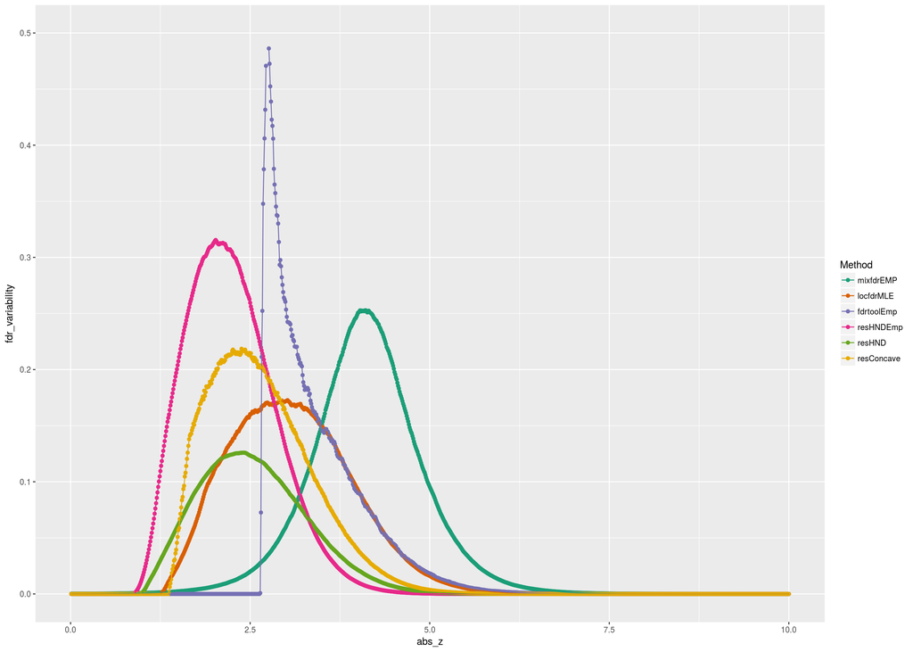

```r
datasd <- lapply(bplapply(fdrResults, function(X){
   return(lapply(X, function(Y){Y$lfdr}))
  }), function(Z){ plyr::mutate(as.data.frame(Z), abs_z=s )})
datasd <- plyr::ldply(datasd, identity)
#test <- plyr::dlply(datasd, "abs_z", identity)
datasd <- plyr::ddply(datasd, "abs_z", apply, 2, mad)
datasd$abs_z <- s
datasd <- melt(datasd,"abs_z", variable.name = "Method",
                 value.name = "fdr_variability")

(qplot(abs_z, fdr_variability, data = datasd, color = Method)
  + geom_line() + ylim(0,0.5)+ scale_color_manual(values = c(pal)))
```

### Null model parameters accuracy plots

## eta0

```r
# ## get accuracy for all methods
dataEta0 <- plyr::ldply(bplapply(fdrResults, function(X){
   return(sapply(X, function(Y){Y$eta_0}))
  }),identity)

dataEta0 <- melt(dataEta0, variable.name = "Method", value.name = "est_eta0")
```

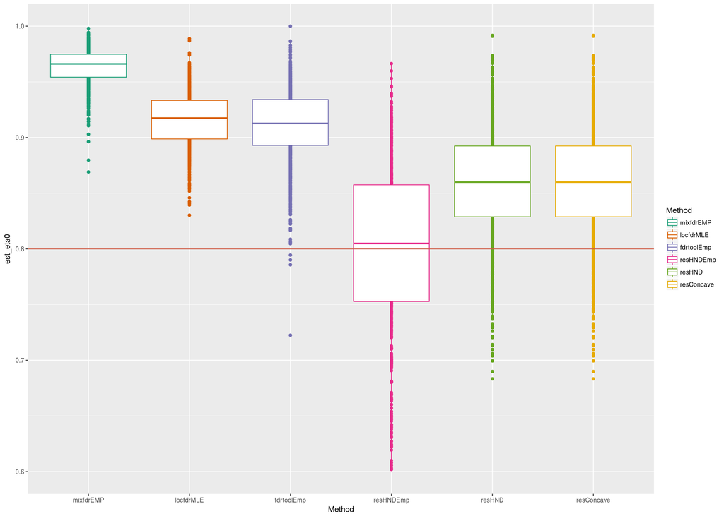

```r
(qplot(Method, est_eta0, data = dataEta0, color = Method)
    + geom_boxplot() + ylim(0.6,1)
  + scale_color_manual(values = c(pal)) + geom_hline(aes(yintercept = eta0), color ="coral3")
 )
```

## sigma

```r
# ## get accuracy for all methods
dataSigma <- plyr::ldply(bplapply(fdrResults, function(X){
   return(sapply(X, function(Y){Y$sigma}))
  }),identity)
dataSigma <- melt(dataSigma, variable.name = "Method", value.name = "est_sigma")
```

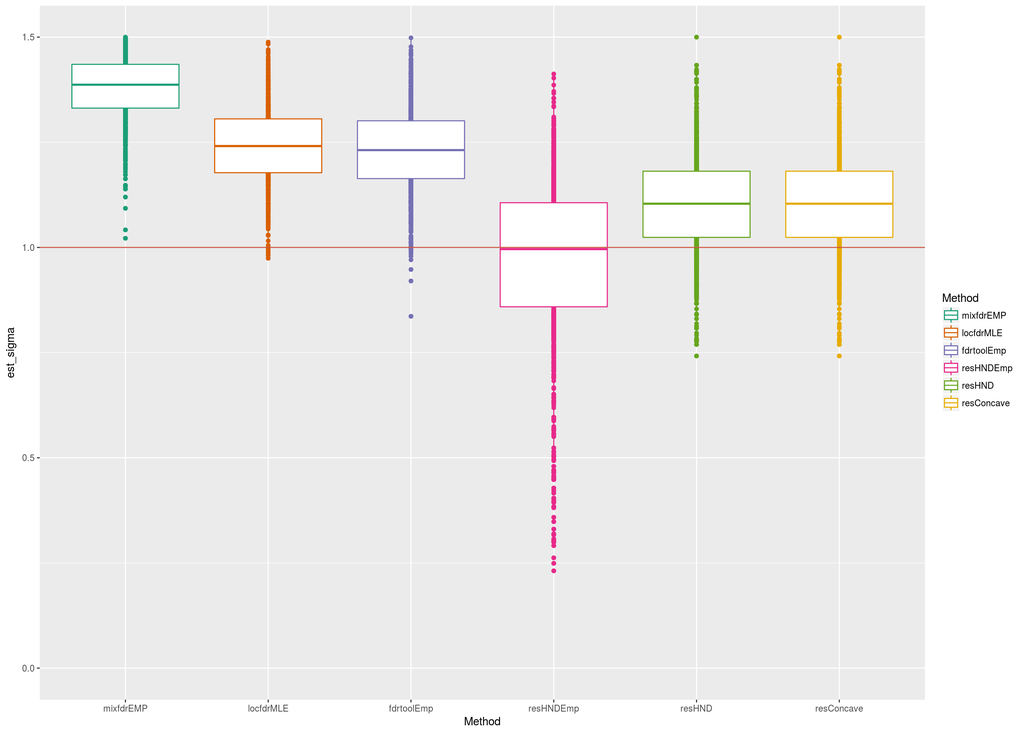

```r
(qplot(Method, est_sigma, data = dataSigma, color = Method)
    + geom_boxplot() + ylim(0,1.5)
  + scale_color_manual(values = c(pal)) + geom_hline(aes(yintercept = sigma),
                                                     color ="coral3")
 )
```